```python
import numpy as np
import pandas as pd
import seaborn as sns
from matplotlib import pyplot as plt
# !pip install missingno
import missingno as msno
from datetime import date
from sklearn.metrics import accuracy_score
from sklearn.model_selection import train_test_split
from sklearn.neighbors import LocalOutlierFactor
from sklearn.model_selection import cross_val_score
from sklearn import metrics
from sklearn.model_selection import GridSearchCV
from sklearn.neighbors import KNeighborsClassifier
from sklearn.impute import KNNImputer
from sklearn.preprocessing import MinMaxScaler, LabelEncoder, StandardScaler, RobustScaler
from sklearn.metrics import roc_curve, roc_auc_score, classification_report, accuracy_score, confusion_matrix
from sklearn.naive_bayes import GaussianNB
from sklearn.metrics import precision_score , recall_score , f1_score , confusion_matrix
from sklearn.metrics import precision_recall_curve , PrecisionRecallDisplay
from sklearn.metrics import roc_curve , RocCurveDisplay , roc_auc_score
from sklearn.model_selection  import cross_val_predict
from sklearn.pipeline import Pipeline
import graphviz
from sklearn.tree import export_graphviz
from sklearn.svm import SVC
from sklearn.tree import DecisionTreeClassifier
from sklearn.ensemble import RandomForestClassifier
from sklearn.linear_model import LogisticRegression
```

# Adjusting visibility of dataframes

```python
pd.set_option('display.max_columns', None)
pd.set_option('display.max_rows', None)
pd.set_option('display.float_format', lambda x: '%.3f' % x)
pd.set_option('display.width', 500)
```

# Reading diabetes data

```python
df=pd.read_csv("diabetes.csv")
```

```python
df.head()
```

|  | Pregnancies | Glucose | BloodPressure | SkinThickness | Insulin | BMI | DiabetesPedigreeFunction | Age | Outcome |
| --- | --- | --- | --- | --- | --- | --- | --- | --- | --- |
| 0 | 6 | 148 | 72 | 35 | 0 | 33.600 | 0.627 | 50 | 1 |
| 1 | 1 | 85 | 66 | 29 | 0 | 26.600 | 0.351 | 31 | 0 |
| 2 | 8 | 183 | 64 | 0 | 0 | 23.300 | 0.672 | 32 | 1 |
| 3 | 1 | 89 | 66 | 23 | 94 | 28.100 | 0.167 | 21 | 0 |
| 4 | 0 | 137 | 40 | 35 | 168 | 43.100 | 2.288 | 33 | 1 |

# Variables Type

```python
print("##################### Shape #####################")
print(df.shape)
print("##################### Types #####################")
print(df.dtypes)
print("##################### NA #####################")
print(df.isnull().sum())
print("##################### Quantiles #####################")
print(df.quantile([0, 0.05, 0.50, 0.95, 0.99, 1]).T)
```

```
##################### Shape #####################
(768, 9)
##################### Types #####################
Pregnancies                   int64
Glucose                       int64
BloodPressure                 int64
SkinThickness                 int64
Insulin                       int64
BMI                         float64
DiabetesPedigreeFunction    float64
Age                           int64
Outcome                       int64
dtype: object
##################### NA #####################
Pregnancies                 0
Glucose                     0
BloodPressure               0
SkinThickness               0
Insulin                     0
BMI                         0
DiabetesPedigreeFunction    0
Age                         0
Outcome                     0
dtype: int64
##################### Quantiles #####################
                          0.000  0.050   0.500   0.950   0.990   1.000
Pregnancies               0.000  0.000   3.000  10.000  13.000  17.000
Glucose                   0.000 79.000 117.000 181.000 196.000 199.000
BloodPressure             0.000 38.700  72.000  90.000 106.000 122.000
SkinThickness             0.000  0.000  23.000  44.000  51.330  99.000
Insulin                   0.000  0.000  30.500 293.000 519.900 846.000
BMI                       0.000 21.800  32.000  44.395  50.759  67.100
DiabetesPedigreeFunction  0.078  0.140   0.372   1.133   1.698   2.420
Age                      21.000 21.000  29.000  58.000  67.000  81.000
Outcome                   0.000  0.000   0.000   1.000   1.000   1.000
```

```python
df.describe().T
```

|  | count | mean | std | min | 25% | 50% | 75% | max |
| --- | --- | --- | --- | --- | --- | --- | --- | --- |
| Pregnancies | 768.000 | 3.845 | 3.370 | 0.000 | 1.000 | 3.000 | 6.000 | 17.000 |
| Glucose | 768.000 | 120.895 | 31.973 | 0.000 | 99.000 | 117.000 | 140.250 | 199.000 |
| BloodPressure | 768.000 | 69.105 | 19.356 | 0.000 | 62.000 | 72.000 | 80.000 | 122.000 |
| SkinThickness | 768.000 | 20.536 | 15.952 | 0.000 | 0.000 | 23.000 | 32.000 | 99.000 |
| Insulin | 768.000 | 79.799 | 115.244 | 0.000 | 0.000 | 30.500 | 127.250 | 846.000 |
| BMI | 768.000 | 31.993 | 7.884 | 0.000 | 27.300 | 32.000 | 36.600 | 67.100 |
| DiabetesPedigreeFunction | 768.000 | 0.472 | 0.331 | 0.078 | 0.244 | 0.372 | 0.626 | 2.420 |
| Age | 768.000 | 33.241 | 11.760 | 21.000 | 24.000 | 29.000 | 41.000 | 81.000 |
| Outcome | 768.000 | 0.349 | 0.477 | 0.000 | 0.000 | 0.000 | 1.000 | 1.000 |

# Giving Constraints to the data to determine which is categorical , which is Numerical and which is Cardinal

```python
def grab_col_names(dataframe, cat_th=3, car_th=20):
    # cat_cols, cat_but_car
    cat_cols = [col for col in dataframe.columns if dataframe[col].dtypes == "O"]
    num_but_cat = [col for col in dataframe.columns if dataframe[col].nunique() < cat_th and
                   dataframe[col].dtypes != "O"]
    cat_but_car = [col for col in dataframe.columns if dataframe[col].nunique() > car_th and
                   dataframe[col].dtypes == "O"]
    cat_cols = cat_cols + num_but_cat
    cat_cols = [col for col in cat_cols if col not in cat_but_car]

    # num_cols
    num_cols = [col for col in dataframe.columns if dataframe[col].dtypes != "O"]
    num_cols = [col for col in num_cols if col not in num_but_cat]

    # report
    print(f"Observations: {dataframe.shape[0]}")
    print(f"Variables: {dataframe.shape[1]}")
    print(f'cat_cols: {len(cat_cols)}')  # the number of categorical variables
    print(f'num_cols: {len(num_cols)}')  # the number of numerical variables
    print(f'cat_but_car: {len(cat_but_car)}')  # the number of cardinal variables
    print(f'num_but_cat: {len(num_but_cat)}')  # the number of categorical variables that looks numerical
    return cat_cols, num_cols, cat_but_car


cat_cols, num_cols, cat_but_car = grab_col_names(df)
```

```
Observations: 768
Variables: 9
cat_cols: 1
num_cols: 8
cat_but_car: 0
num_but_cat: 1
```

# Printing types of columns

```python
print("Categorical columns:",cat_cols)
print("Numerical columns:", num_cols)
print("Cardinal columns:", cat_but_car)
```

```
Categorical columns: ['Outcome']
Numerical columns: ['Pregnancies', 'Glucose', 'BloodPressure', 'SkinThickness', 'Insulin', 'BMI', 'DiabetesPedigreeFunction', 'Age']
Cardinal columns: []
```

# The average of the numerical variables according to the target variable

```python
df.groupby(cat_cols)[num_cols].mean()
```

| Outcome | Pregnancies | Glucose | BloodPressure | SkinThickness | Insulin | BMI | DiabetesPedigreeFunction | Age |
| --- | --- | --- | --- | --- | --- | --- | --- | --- |
| 0 | 3.298 | 109.980 | 68.184 | 19.664 | 68.792 | 30.304 | 0.430 | 31.190 |
| 1 | 4.866 | 141.257 | 70.825 | 22.164 | 100.336 | 35.143 | 0.550 | 37.067 |

# Calculating the mean of the categorical column

```python
df[cat_cols].mean()
```

```
Outcome   0.349
dtype: float64
```

# Analyzing the outcom column into disease and no disease

```python
print(df.Outcome.value_counts())
print("-------------------------------")
print(df[cat_cols].mean())
print("-------------------------------")
print("Ratio: ")
(df.Outcome.value_counts() / len(df)) *100
```

```
0    500
1    268
Name: Outcome, dtype: int64
-------------------------------
Outcome   0.349
dtype: float64
-------------------------------
Ratio:
```

```
0   65.104
1   34.896
Name: Outcome, dtype: float64
```

# Using Boxplot(interquartile range-IQR) method to determine the outliers

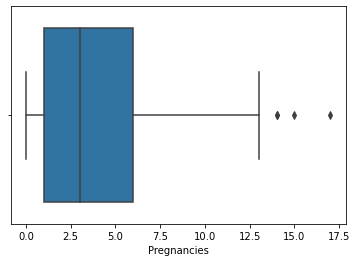

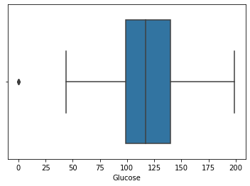

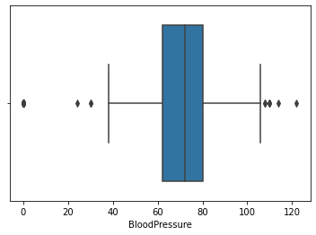

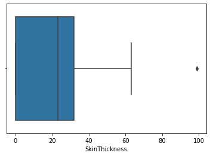

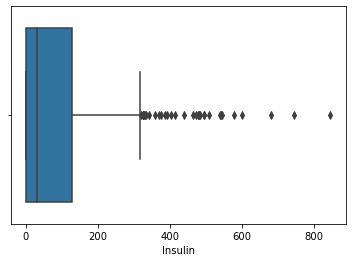

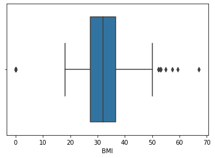

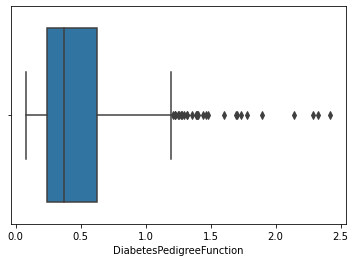

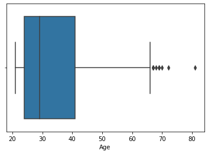

```python
sns.boxplot(x=df["Pregnancies"])
plt.show()

sns.boxplot(x=df["Glucose"])
plt.show()

sns.boxplot(x=df["BloodPressure"])
plt.show()

sns.boxplot(x=df["SkinThickness"])
plt.show()

sns.boxplot(x=df["Insulin"])
plt.show()

sns.boxplot(x=df["BMI"])
plt.show()

sns.boxplot(x=df["DiabetesPedigreeFunction"])
plt.show()

sns.boxplot(x=df["Age"])
plt.show()
```

# Calculating the upper and lower thresholds

```python
def outlier_thresholds(dataframe, col_name, q1=0.25, q3=0.75):
    quartile1 = dataframe[col_name].quantile(q1)
    quartile3 = dataframe[col_name].quantile(q3)
    interquantile_range = quartile3 - quartile1
    up_limit = quartile3 + 1.5 * interquantile_range
    low_limit = quartile1 - 1.5 * interquantile_range
    return low_limit, up_limit
```

```python
for i in df.columns:
    print("Thresholds of {} : ({:.2f}, {:.2f})".format(i, *outlier_thresholds(df,i)))
```

```
Thresholds of Pregnancies : (-6.50, 13.50)
Thresholds of Glucose : (37.12, 202.12)
Thresholds of BloodPressure : (35.00, 107.00)
Thresholds of SkinThickness : (-48.00, 80.00)
Thresholds of Insulin : (-190.88, 318.12)
Thresholds of BMI : (13.35, 50.55)
Thresholds of DiabetesPedigreeFunction : (-0.33, 1.20)
Thresholds of Age : (-1.50, 66.50)
Thresholds of Outcome : (-1.50, 2.50)
```

# Displaying the pregnancies which has value above or below the threshold

```python
low, up = outlier_thresholds(df, "Pregnancies")
df[((df["Pregnancies"] < low) | (df["Pregnancies"] > up))]
```

|  | Pregnancies | Glucose | BloodPressure | SkinThickness | Insulin | BMI | DiabetesPedigreeFunction | Age | Outcome |
| --- | --- | --- | --- | --- | --- | --- | --- | --- | --- |
| 88 | 15 | 136 | 70 | 32 | 110 | 37.100 | 0.153 | 43 | 1 |
| 159 | 17 | 163 | 72 | 41 | 114 | 40.900 | 0.817 | 47 | 1 |
| 298 | 14 | 100 | 78 | 25 | 184 | 36.600 | 0.412 | 46 | 1 |
| 455 | 14 | 175 | 62 | 30 | 0 | 33.600 | 0.212 | 38 | 1 |

# Searching for any missing values in any column

```python
df.isnull().values.any()
```

```
False
```

```python
df.isnull().sum()
```

```
Pregnancies                 0
Glucose                     0
BloodPressure               0
SkinThickness               0
Insulin                     0
BMI                         0
DiabetesPedigreeFunction    0
Age                         0
Outcome                     0
dtype: int64
```

# Assigning 0 value as NaN for all columns except pregnancies

```python
num_cols_miss = [i for i in num_cols if i != "Pregnancies"]
for i in num_cols_miss:
    df[i] = df.apply(lambda x: np.nan if x[i] == 0 else x[i], axis=1)
```

```python
df.head(768)
```

|  | Pregnancies | Glucose | BloodPressure | SkinThickness | Insulin | BMI | DiabetesPedigreeFunction | Age | Outcome |
| --- | --- | --- | --- | --- | --- | --- | --- | --- | --- |
| 0 | 6 | 148.000 | 72.000 | 35.000 | NaN | 33.600 | 0.627 | 50.000 | 1 |
| 1 | 1 | 85.000 | 66.000 | 29.000 | NaN | 26.600 | 0.351 | 31.000 | 0 |
| 2 | 8 | 183.000 | 64.000 | NaN | NaN | 23.300 | 0.672 | 32.000 | 1 |
| 3 | 1 | 89.000 | 66.000 | 23.000 | 94.000 | 28.100 | 0.167 | 21.000 | 0 |
| 4 | 0 | 137.000 | 40.000 | 35.000 | 168.000 | 43.100 | 2.288 | 33.000 | 1 |
| 5 | 5 | 116.000 | 74.000 | NaN | NaN | 25.600 | 0.201 | 30.000 | 0 |
| 6 | 3 | 78.000 | 50.000 | 32.000 | 88.000 | 31.000 | 0.248 | 26.000 | 1 |
| 7 | 10 | 115.000 | NaN | NaN | NaN | 35.300 | 0.134 | 29.000 | 0 |
| 8 | 2 | 197.000 | 70.000 | 45.000 | 543.000 | 30.500 | 0.158 | 53.000 | 1 |
| 9 | 8 | 125.000 | 96.000 | NaN | NaN | NaN | 0.232 | 54.000 | 1 |
| 10 | 4 | 110.000 | 92.000 | NaN | NaN | 37.600 | 0.191 | 30.000 | 0 |
| 11 | 10 | 168.000 | 74.000 | NaN | NaN | 38.000 | 0.537 | 34.000 | 1 |
| 12 | 10 | 139.000 | 80.000 | NaN | NaN | 27.100 | 1.441 | 57.000 | 0 |
| 13 | 1 | 189.000 | 60.000 | 23.000 | 846.000 | 30.100 | 0.398 | 59.000 | 1 |
| 14 | 5 | 166.000 | 72.000 | 19.000 | 175.000 | 25.800 | 0.587 | 51.000 | 1 |
| 15 | 7 | 100.000 | NaN | NaN | NaN | 30.000 | 0.484 | 32.000 | 1 |
| 16 | 0 | 118.000 | 84.000 | 47.000 | 230.000 | 45.800 | 0.551 | 31.000 | 1 |
| 17 | 7 | 107.000 | 74.000 | NaN | NaN | 29.600 | 0.254 | 31.000 | 1 |
| 18 | 1 | 103.000 | 30.000 | 38.000 | 83.000 | 43.300 | 0.183 | 33.000 | 0 |
| 19 | 1 | 115.000 | 70.000 | 30.000 | 96.000 | 34.600 | 0.529 | 32.000 | 1 |
| 20 | 3 | 126.000 | 88.000 | 41.000 | 235.000 | 39.300 | 0.704 | 27.000 | 0 |
| 21 | 8 | 99.000 | 84.000 | NaN | NaN | 35.400 | 0.388 | 50.000 | 0 |
| 22 | 7 | 196.000 | 90.000 | NaN | NaN | 39.800 | 0.451 | 41.000 | 1 |
| 23 | 9 | 119.000 | 80.000 | 35.000 | NaN | 29.000 | 0.263 | 29.000 | 1 |
| 24 | 11 | 143.000 | 94.000 | 33.000 | 146.000 | 36.600 | 0.254 | 51.000 | 1 |
| 25 | 10 | 125.000 | 70.000 | 26.000 | 115.000 | 31.100 | 0.205 | 41.000 | 1 |
| 26 | 7 | 147.000 | 76.000 | NaN | NaN | 39.400 | 0.257 | 43.000 | 1 |
| 27 | 1 | 97.000 | 66.000 | 15.000 | 140.000 | 23.200 | 0.487 | 22.000 | 0 |
| 28 | 13 | 145.000 | 82.000 | 19.000 | 110.000 | 22.200 | 0.245 | 57.000 | 0 |
| 29 | 5 | 117.000 | 92.000 | NaN | NaN | 34.100 | 0.337 | 38.000 | 0 |

[output cut: 738 more lines]

# Counting the NaN values in each column

```python
df.isnull().sum()
```

```
Pregnancies                   0
Glucose                       5
BloodPressure                35
SkinThickness               227
Insulin                     374
BMI                          11
DiabetesPedigreeFunction      0
Age                           0
Outcome                       0
dtype: int64
```

# Plotting the NaN data in each column

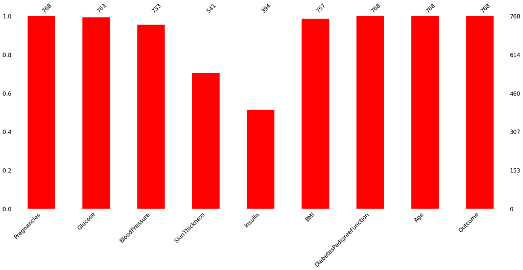

```python
msno.bar(df,color="Red")
plt.show()
```

# Heatmap used to display the correlation of NaN on variables

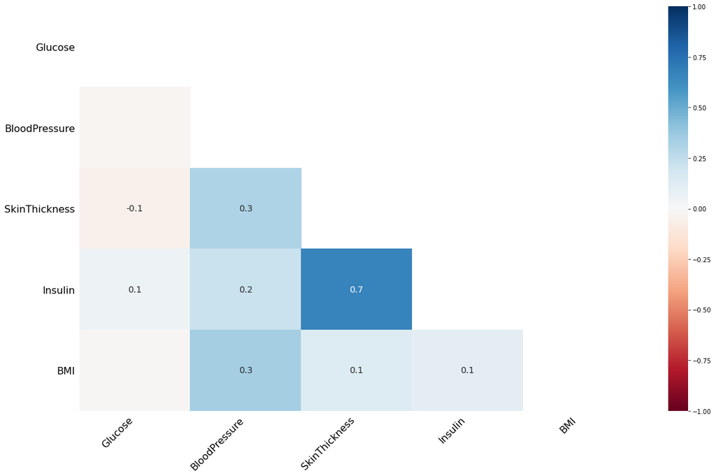

```python
msno.heatmap(df)
plt.show()
```

# Counting the Missing values in each column and display it

```python
def missing_values_table(dataframe, na_name=False):
    # only take missing columns
    na_columns = [col for col in dataframe.columns if dataframe[col].isnull().sum() > 0]

    n_miss = dataframe[na_columns].isnull().sum().sort_values(ascending=False)  # number of missing value
    ratio = (dataframe[na_columns].isnull().sum() / dataframe.shape[0] * 100).sort_values(ascending=False) # ratio
    missing_df = pd.concat([n_miss, np.round(ratio, 2)], axis=1, keys=['n_miss', 'ratio'])  # make table
    print(missing_df, end="\n")

    if na_name:
        return na_columns
```

```python
missing_values_table(df)
```

```
               n_miss  ratio
Insulin           374 48.700
SkinThickness     227 29.560
BloodPressure      35  4.560
BMI                11  1.430
Glucose             5  0.650
```

# Printning only the lines that contains missing values

```python
na_cols = missing_values_table(df, na_name=True)
na_cols
```

```
               n_miss  ratio
Insulin           374 48.700
SkinThickness     227 29.560
BloodPressure      35  4.560
BMI                11  1.430
Glucose             5  0.650
```

```
['Glucose', 'BloodPressure', 'SkinThickness', 'Insulin', 'BMI']
```

# Counting Missed values for each column, 1 means missed value

```python
def missing_vs_target(dataframe, target, na_columns):
    temp_df = dataframe.copy()

    for col in na_columns:
        temp_df[col + '_NA_FLAG'] = np.where(temp_df[col].isnull(), 1, 0)  # eksiklik varsa 1, yoksa 0 yaz

    # [tüm satırları getir, sütunlarda içinde NA olanları getir]
    na_flags = temp_df.loc[:, temp_df.columns.str.contains("_NA_")].columns

    for col in na_flags:
        print(pd.DataFrame({"Count": temp_df.groupby(col)[target].count()}), end="\n\n\n")


missing_vs_target(df, "Outcome", na_cols)
```

```
                 Count
Glucose_NA_FLAG
0                  763
1                    5


                       Count
BloodPressure_NA_FLAG
0                        733
1                         35


                       Count
SkinThickness_NA_FLAG
0                        541
1                        227


                 Count
Insulin_NA_FLAG
0                  394
1                  374


             Count
BMI_NA_FLAG
0              757
1               11
```

# Displaying the correlation of variables

```python
df_cor = pd.DataFrame([df["Outcome"].corr(df[i]) for i in num_cols], index=num_cols, columns=["Correlation"])
df_cor
```

|  | Correlation |
| --- | --- |
| Pregnancies | 0.222 |
| Glucose | 0.495 |
| BloodPressure | 0.171 |
| SkinThickness | 0.259 |
| Insulin | 0.303 |
| BMI | 0.314 |
| DiabetesPedigreeFunction | 0.174 |
| Age | 0.238 |

# Filling the NaN values with median of each column

```python
df_fill = df.apply(lambda x: x.fillna(x.median()) if x.dtype != "O" else x, axis=0)
df_fill.head(10) # after filling
```

|  | Pregnancies | Glucose | BloodPressure | SkinThickness | Insulin | BMI | DiabetesPedigreeFunction | Age | Outcome |
| --- | --- | --- | --- | --- | --- | --- | --- | --- | --- |
| 0 | 6 | 148.000 | 72.000 | 35.000 | 125.000 | 33.600 | 0.627 | 50.000 | 1 |
| 1 | 1 | 85.000 | 66.000 | 29.000 | 125.000 | 26.600 | 0.351 | 31.000 | 0 |
| 2 | 8 | 183.000 | 64.000 | 29.000 | 125.000 | 23.300 | 0.672 | 32.000 | 1 |
| 3 | 1 | 89.000 | 66.000 | 23.000 | 94.000 | 28.100 | 0.167 | 21.000 | 0 |
| 4 | 0 | 137.000 | 40.000 | 35.000 | 168.000 | 43.100 | 2.288 | 33.000 | 1 |
| 5 | 5 | 116.000 | 74.000 | 29.000 | 125.000 | 25.600 | 0.201 | 30.000 | 0 |
| 6 | 3 | 78.000 | 50.000 | 32.000 | 88.000 | 31.000 | 0.248 | 26.000 | 1 |
| 7 | 10 | 115.000 | 72.000 | 29.000 | 125.000 | 35.300 | 0.134 | 29.000 | 0 |
| 8 | 2 | 197.000 | 70.000 | 45.000 | 543.000 | 30.500 | 0.158 | 53.000 | 1 |
| 9 | 8 | 125.000 | 96.000 | 29.000 | 125.000 | 32.300 | 0.232 | 54.000 | 1 |

# Before Filling the NaN values

```python
df.head(10)
```

|  | Pregnancies | Glucose | BloodPressure | SkinThickness | Insulin | BMI | DiabetesPedigreeFunction | Age | Outcome |
| --- | --- | --- | --- | --- | --- | --- | --- | --- | --- |
| 0 | 6 | 148.000 | 72.000 | 35.000 | NaN | 33.600 | 0.627 | 50.000 | 1 |
| 1 | 1 | 85.000 | 66.000 | 29.000 | NaN | 26.600 | 0.351 | 31.000 | 0 |
| 2 | 8 | 183.000 | 64.000 | NaN | NaN | 23.300 | 0.672 | 32.000 | 1 |
| 3 | 1 | 89.000 | 66.000 | 23.000 | 94.000 | 28.100 | 0.167 | 21.000 | 0 |
| 4 | 0 | 137.000 | 40.000 | 35.000 | 168.000 | 43.100 | 2.288 | 33.000 | 1 |
| 5 | 5 | 116.000 | 74.000 | NaN | NaN | 25.600 | 0.201 | 30.000 | 0 |
| 6 | 3 | 78.000 | 50.000 | 32.000 | 88.000 | 31.000 | 0.248 | 26.000 | 1 |
| 7 | 10 | 115.000 | NaN | NaN | NaN | 35.300 | 0.134 | 29.000 | 0 |
| 8 | 2 | 197.000 | 70.000 | 45.000 | 543.000 | 30.500 | 0.158 | 53.000 | 1 |
| 9 | 8 | 125.000 | 96.000 | NaN | NaN | NaN | 0.232 | 54.000 | 1 |

# Filling Missed Values with predictive Methods (KNN Algorithm)

## Normalizing data because Knn is a distance based algorithm

```python
df_ml = df.copy()

scaler = MinMaxScaler()
df_ml = pd.DataFrame(scaler.fit_transform(df_ml), columns=df_ml.columns)
df_ml.head()
```

|  | Pregnancies | Glucose | BloodPressure | SkinThickness | Insulin | BMI | DiabetesPedigreeFunction | Age | Outcome |
| --- | --- | --- | --- | --- | --- | --- | --- | --- | --- |
| 0 | 0.353 | 0.671 | 0.490 | 0.304 | NaN | 0.315 | 0.234 | 0.483 | 1.000 |
| 1 | 0.059 | 0.265 | 0.429 | 0.239 | NaN | 0.172 | 0.117 | 0.167 | 0.000 |
| 2 | 0.471 | 0.897 | 0.408 | NaN | NaN | 0.104 | 0.254 | 0.183 | 1.000 |
| 3 | 0.059 | 0.290 | 0.429 | 0.174 | 0.096 | 0.202 | 0.038 | 0.000 | 0.000 |
| 4 | 0.000 | 0.600 | 0.163 | 0.304 | 0.185 | 0.509 | 0.944 | 0.200 | 1.000 |

## Filling missed values with KNN

```python
imputer = KNNImputer(n_neighbors=5)
df_ml = pd.DataFrame(imputer.fit_transform(df_ml), columns=df_ml.columns)
df_ml.head(10)
```

|  | Pregnancies | Glucose | BloodPressure | SkinThickness | Insulin | BMI | DiabetesPedigreeFunction | Age | Outcome |
| --- | --- | --- | --- | --- | --- | --- | --- | --- | --- |
| 0 | 0.353 | 0.671 | 0.490 | 0.304 | 0.385 | 0.315 | 0.234 | 0.483 | 1.000 |
| 1 | 0.059 | 0.265 | 0.429 | 0.239 | 0.051 | 0.172 | 0.117 | 0.167 | 0.000 |
| 2 | 0.471 | 0.897 | 0.408 | 0.274 | 0.269 | 0.104 | 0.254 | 0.183 | 1.000 |
| 3 | 0.059 | 0.290 | 0.429 | 0.174 | 0.096 | 0.202 | 0.038 | 0.000 | 0.000 |
| 4 | 0.000 | 0.600 | 0.163 | 0.304 | 0.185 | 0.509 | 0.944 | 0.200 | 1.000 |
| 5 | 0.294 | 0.465 | 0.510 | 0.174 | 0.138 | 0.151 | 0.053 | 0.150 | 0.000 |
| 6 | 0.176 | 0.219 | 0.265 | 0.272 | 0.089 | 0.262 | 0.073 | 0.083 | 1.000 |
| 7 | 0.588 | 0.458 | 0.490 | 0.270 | 0.187 | 0.350 | 0.024 | 0.133 | 0.000 |
| 8 | 0.118 | 0.987 | 0.469 | 0.413 | 0.636 | 0.252 | 0.034 | 0.533 | 1.000 |
| 9 | 0.471 | 0.523 | 0.735 | 0.274 | 0.331 | 0.319 | 0.066 | 0.550 | 1.000 |

## Returning data from normalization

```python
df_ml = pd.DataFrame(scaler.inverse_transform(df_ml), columns=df_ml.columns)
df_ml.head(10)
```

|  | Pregnancies | Glucose | BloodPressure | SkinThickness | Insulin | BMI | DiabetesPedigreeFunction | Age | Outcome |
| --- | --- | --- | --- | --- | --- | --- | --- | --- | --- |
| 0 | 6.000 | 148.000 | 72.000 | 35.000 | 334.200 | 33.600 | 0.627 | 50.000 | 1.000 |
| 1 | 1.000 | 85.000 | 66.000 | 29.000 | 56.200 | 26.600 | 0.351 | 31.000 | 0.000 |
| 2 | 8.000 | 183.000 | 64.000 | 32.200 | 238.000 | 23.300 | 0.672 | 32.000 | 1.000 |
| 3 | 1.000 | 89.000 | 66.000 | 23.000 | 94.000 | 28.100 | 0.167 | 21.000 | 0.000 |
| 4 | 0.000 | 137.000 | 40.000 | 35.000 | 168.000 | 43.100 | 2.288 | 33.000 | 1.000 |
| 5 | 5.000 | 116.000 | 74.000 | 23.000 | 128.400 | 25.600 | 0.201 | 30.000 | 0.000 |
| 6 | 3.000 | 78.000 | 50.000 | 32.000 | 88.000 | 31.000 | 0.248 | 26.000 | 1.000 |
| 7 | 10.000 | 115.000 | 72.000 | 31.800 | 169.600 | 35.300 | 0.134 | 29.000 | 0.000 |
| 8 | 2.000 | 197.000 | 70.000 | 45.000 | 543.000 | 30.500 | 0.158 | 53.000 | 1.000 |
| 9 | 8.000 | 125.000 | 96.000 | 32.200 | 289.200 | 33.780 | 0.232 | 54.000 | 1.000 |

```python
## Data before filling
df.head(10)
```

|  | Pregnancies | Glucose | BloodPressure | SkinThickness | Insulin | BMI | DiabetesPedigreeFunction | Age | Outcome |
| --- | --- | --- | --- | --- | --- | --- | --- | --- | --- |
| 0 | 6 | 148.000 | 72.000 | 35.000 | NaN | 33.600 | 0.627 | 50.000 | 1 |
| 1 | 1 | 85.000 | 66.000 | 29.000 | NaN | 26.600 | 0.351 | 31.000 | 0 |
| 2 | 8 | 183.000 | 64.000 | NaN | NaN | 23.300 | 0.672 | 32.000 | 1 |
| 3 | 1 | 89.000 | 66.000 | 23.000 | 94.000 | 28.100 | 0.167 | 21.000 | 0 |
| 4 | 0 | 137.000 | 40.000 | 35.000 | 168.000 | 43.100 | 2.288 | 33.000 | 1 |
| 5 | 5 | 116.000 | 74.000 | NaN | NaN | 25.600 | 0.201 | 30.000 | 0 |
| 6 | 3 | 78.000 | 50.000 | 32.000 | 88.000 | 31.000 | 0.248 | 26.000 | 1 |
| 7 | 10 | 115.000 | NaN | NaN | NaN | 35.300 | 0.134 | 29.000 | 0 |
| 8 | 2 | 197.000 | 70.000 | 45.000 | 543.000 | 30.500 | 0.158 | 53.000 | 1 |
| 9 | 8 | 125.000 | 96.000 | NaN | NaN | NaN | 0.232 | 54.000 | 1 |

# Dividing the columns according to which filling method will be used

```python
na_cols = missing_values_table(df, na_name=True) # columns that includes missing values
n_miss = df[na_cols].isnull().sum() # number of missing values on variables

# 100 as a threshold, it is open to comment
na_cols_ml = [i for i in n_miss.index if n_miss[i] < 120]
na_cols_med = [i for i in n_miss.index if n_miss[i] > 120]
print("Columns that will be applied ML model:", na_cols_ml)
print("Columns that will be filled with median:", na_cols_med)
```

```
               n_miss  ratio
Insulin           374 48.700
SkinThickness     227 29.560
BloodPressure      35  4.560
BMI                11  1.430
Glucose             5  0.650
Columns that will be applied ML model: ['Glucose', 'BloodPressure', 'BMI']
Columns that will be filled with median: ['SkinThickness', 'Insulin']
```

```python
df[na_cols_med] = df[na_cols_med].apply(lambda x: x.fillna(x.median()) if x.dtype != "O" else x, axis=0)
df.head(10)
```

|  | Pregnancies | Glucose | BloodPressure | SkinThickness | Insulin | BMI | DiabetesPedigreeFunction | Age | Outcome |
| --- | --- | --- | --- | --- | --- | --- | --- | --- | --- |
| 0 | 6 | 148.000 | 72.000 | 35.000 | 125.000 | 33.600 | 0.627 | 50.000 | 1 |
| 1 | 1 | 85.000 | 66.000 | 29.000 | 125.000 | 26.600 | 0.351 | 31.000 | 0 |
| 2 | 8 | 183.000 | 64.000 | 29.000 | 125.000 | 23.300 | 0.672 | 32.000 | 1 |
| 3 | 1 | 89.000 | 66.000 | 23.000 | 94.000 | 28.100 | 0.167 | 21.000 | 0 |
| 4 | 0 | 137.000 | 40.000 | 35.000 | 168.000 | 43.100 | 2.288 | 33.000 | 1 |
| 5 | 5 | 116.000 | 74.000 | 29.000 | 125.000 | 25.600 | 0.201 | 30.000 | 0 |
| 6 | 3 | 78.000 | 50.000 | 32.000 | 88.000 | 31.000 | 0.248 | 26.000 | 1 |
| 7 | 10 | 115.000 | NaN | 29.000 | 125.000 | 35.300 | 0.134 | 29.000 | 0 |
| 8 | 2 | 197.000 | 70.000 | 45.000 | 543.000 | 30.500 | 0.158 | 53.000 | 1 |
| 9 | 8 | 125.000 | 96.000 | 29.000 | 125.000 | NaN | 0.232 | 54.000 | 1 |

```python
# Normalization
scaler = MinMaxScaler()
# Standerizing the required columns which the predictive model will be applied to

df[na_cols_ml] = pd.DataFrame(scaler.fit_transform(df[na_cols_ml]), columns=df[na_cols_ml].columns)

# Filling with KNN
imputer = KNNImputer(n_neighbors=5)
df[na_cols_ml] = pd.DataFrame(imputer.fit_transform(df[na_cols_ml]), columns=df[na_cols_ml].columns)

#APPLYING FILLED DATA TO THE MAIN DATA
df[na_cols_ml] = pd.DataFrame(scaler.inverse_transform(df[na_cols_ml]), columns=df[na_cols_ml].columns)
print(df[na_cols_ml].head(10))
```

```
   Glucose  BloodPressure    BMI
0  148.000         72.000 33.600
1   85.000         66.000 26.600
2  183.000         64.000 23.300
3   89.000         66.000 28.100
4  137.000         40.000 43.100
5  116.000         74.000 25.600
6   78.000         50.000 31.000
7  115.000         78.200 35.300
8  197.000         70.000 30.500
9  125.000         96.000 31.100
```

# Displaying Data after filling the missed values with Median method And Predictive Method (KNN)

```python
df.head(10)
```

|  | Pregnancies | Glucose | BloodPressure | SkinThickness | Insulin | BMI | DiabetesPedigreeFunction | Age | Outcome |
| --- | --- | --- | --- | --- | --- | --- | --- | --- | --- |
| 0 | 6 | 148.000 | 72.000 | 35.000 | 125.000 | 33.600 | 0.627 | 50.000 | 1 |
| 1 | 1 | 85.000 | 66.000 | 29.000 | 125.000 | 26.600 | 0.351 | 31.000 | 0 |
| 2 | 8 | 183.000 | 64.000 | 29.000 | 125.000 | 23.300 | 0.672 | 32.000 | 1 |
| 3 | 1 | 89.000 | 66.000 | 23.000 | 94.000 | 28.100 | 0.167 | 21.000 | 0 |
| 4 | 0 | 137.000 | 40.000 | 35.000 | 168.000 | 43.100 | 2.288 | 33.000 | 1 |
| 5 | 5 | 116.000 | 74.000 | 29.000 | 125.000 | 25.600 | 0.201 | 30.000 | 0 |
| 6 | 3 | 78.000 | 50.000 | 32.000 | 88.000 | 31.000 | 0.248 | 26.000 | 1 |
| 7 | 10 | 115.000 | 78.200 | 29.000 | 125.000 | 35.300 | 0.134 | 29.000 | 0 |
| 8 | 2 | 197.000 | 70.000 | 45.000 | 543.000 | 30.500 | 0.158 | 53.000 | 1 |
| 9 | 8 | 125.000 | 96.000 | 29.000 | 125.000 | 31.100 | 0.232 | 54.000 | 1 |

# Checking if there is a NaN value in the columns

```python
df.isnull().sum()
```

```
Pregnancies                 0
Glucose                     0
BloodPressure               0
SkinThickness               0
Insulin                     0
BMI                         0
DiabetesPedigreeFunction    0
Age                         0
Outcome                     0
dtype: int64
```

# Removing outlier

## First method we going to use is LOF (Multi-Variate) to identify the outlier based on density deviation of a given data point with respect to its neighbors

```python
## Getting the scores required for LOF for each column
clf = LocalOutlierFactor(n_neighbors=20)
clf.fit_predict(df)  # returns LOF scores
df_scores = clf.negative_outlier_factor_ # keep scores to observe (negative)
# for changing to positive but we will use as negative
print(df_scores[0:5])
print(np.sort(df_scores)[0:5])
```

```
[-1.01906445 -0.99569451 -1.0618044  -0.99166551 -1.27903361]
[-2.80654993 -2.59693313 -2.4153327  -2.02605837 -1.99003552]
```

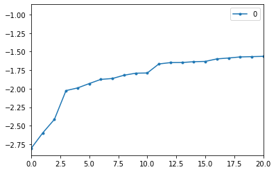

```python
# elbow mehtod
scores = pd.DataFrame(np.sort(df_scores))
scores.plot(stacked=True, xlim=[0, 20], style='.-')  # x=gözlemler, y=outlier skorları
plt.show()
```

#### y-axis represents outlier scores , x-axis represent observations from the graph we want to determine the thershold value , it will be determined on the where the steepest slop occur , so from the above graph we notice that the 3rd index is that point , so a threshold has to be set and cut it,

```python
th = np.sort(df_scores)[3]  # set any lower scores than that as outlier
df[df_scores < th] # check outliers
```

|  | Pregnancies | Glucose | BloodPressure | SkinThickness | Insulin | BMI | DiabetesPedigreeFunction | Age | Outcome |
| --- | --- | --- | --- | --- | --- | --- | --- | --- | --- |
| 13 | 1 | 189.000 | 60.000 | 23.000 | 846.000 | 30.100 | 0.398 | 59.000 | 1 |
| 445 | 0 | 180.000 | 78.000 | 63.000 | 14.000 | 59.400 | 2.420 | 25.000 | 1 |
| 579 | 2 | 197.000 | 70.000 | 99.000 | 125.000 | 34.700 | 0.575 | 62.000 | 1 |

# These three outliers can be removed as they represents unacceptable combinations

```python
# deleting the 13,445 and 579 indecies as they represent unacceptable combinations
print("Before delete outliers:", df.shape)
print(df[df_scores < th].index)
df.drop(axis=0, labels=df[df_scores < th].index, inplace=True)
print("After delete outliers:", df.shape)
```

```
Before delete outliers: (768, 9)
Int64Index([13, 445, 579], dtype='int64')
After delete outliers: (765, 9)
```

# Using IQR to calculate threshold for each column

```python
def replace_with_thresholds(dataframe, variable):
    low_limit, up_limit = outlier_thresholds(dataframe, variable)
    dataframe.loc[(dataframe[variable] < low_limit), variable] = low_limit
    dataframe.loc[(dataframe[variable] > up_limit), variable] = up_limit
```

```python
# data set before replacing the threshold
df.describe().T
```

|  | count | mean | std | min | 25% | 50% | 75% | max |
| --- | --- | --- | --- | --- | --- | --- | --- | --- |
| Pregnancies | 765.000 | 3.856 | 3.371 | 0.000 | 1.000 | 3.000 | 6.000 | 17.000 |
| Glucose | 765.000 | 121.418 | 30.209 | 44.000 | 99.000 | 117.000 | 140.000 | 199.000 |
| BloodPressure | 765.000 | 72.428 | 12.216 | 24.000 | 64.000 | 72.000 | 80.000 | 122.000 |
| SkinThickness | 765.000 | 28.980 | 8.344 | 7.000 | 25.000 | 29.000 | 32.000 | 60.000 |
| Insulin | 765.000 | 139.936 | 82.573 | 15.000 | 122.000 | 125.000 | 127.000 | 744.000 |
| BMI | 765.000 | 32.426 | 6.826 | 18.200 | 27.500 | 32.300 | 36.600 | 67.100 |
| DiabetesPedigreeFunction | 765.000 | 0.469 | 0.324 | 0.078 | 0.243 | 0.370 | 0.626 | 2.329 |
| Age | 765.000 | 33.180 | 11.696 | 21.000 | 24.000 | 29.000 | 41.000 | 81.000 |
| Outcome | 765.000 | 0.346 | 0.476 | 0.000 | 0.000 | 0.000 | 1.000 | 1.000 |

```python
# Replacing threshold with the calculated one
for col in num_cols:
    replace_with_thresholds(df, col)

#displaying data after replacing the threshold
df.describe().T
```

|  | count | mean | std | min | 25% | 50% | 75% | max |
| --- | --- | --- | --- | --- | --- | --- | --- | --- |
| Pregnancies | 765.000 | 3.848 | 3.346 | 0.000 | 1.000 | 3.000 | 6.000 | 13.500 |
| Glucose | 765.000 | 121.418 | 30.209 | 44.000 | 99.000 | 117.000 | 140.000 | 199.000 |
| BloodPressure | 765.000 | 72.399 | 11.819 | 40.000 | 64.000 | 72.000 | 80.000 | 104.000 |
| SkinThickness | 765.000 | 28.839 | 7.421 | 14.500 | 25.000 | 29.000 | 32.000 | 42.500 |
| Insulin | 765.000 | 124.745 | 6.918 | 114.500 | 122.000 | 125.000 | 127.000 | 134.500 |
| BMI | 765.000 | 32.375 | 6.657 | 18.200 | 27.500 | 32.300 | 36.600 | 50.250 |
| DiabetesPedigreeFunction | 765.000 | 0.458 | 0.285 | 0.078 | 0.243 | 0.370 | 0.626 | 1.200 |
| Age | 765.000 | 33.139 | 11.563 | 21.000 | 24.000 | 29.000 | 41.000 | 66.500 |
| Outcome | 765.000 | 0.346 | 0.476 | 0.000 | 0.000 | 0.000 | 1.000 | 1.000 |

### As it can be seen, min, max, event mean, and std values have changed according to calculated thresholds.

# Applying Models

```python
X = df.drop(columns=['Outcome'])
y = df['Outcome'].values
X.head()
```

|  | Pregnancies | Glucose | BloodPressure | SkinThickness | Insulin | BMI | DiabetesPedigreeFunction | Age |
| --- | --- | --- | --- | --- | --- | --- | --- | --- |
| 0 | 6.000 | 148.000 | 72.000 | 35.000 | 125.000 | 33.600 | 0.627 | 50.000 |
| 1 | 1.000 | 85.000 | 66.000 | 29.000 | 125.000 | 26.600 | 0.351 | 31.000 |
| 2 | 8.000 | 183.000 | 64.000 | 29.000 | 125.000 | 23.300 | 0.672 | 32.000 |
| 3 | 1.000 | 89.000 | 66.000 | 23.000 | 114.500 | 28.100 | 0.167 | 21.000 |
| 4 | 0.000 | 137.000 | 40.000 | 35.000 | 134.500 | 43.100 | 1.200 | 33.000 |

```python
X_train, X_test, y_train, y_test = train_test_split(X, y, test_size=0.15, random_state=17)
print(X_train.shape)
print(X_test.shape)
```

```
(650, 8)
(115, 8)
```

## Applying KNN Model

### Choosing the best hyper-parameter (K) From 1 to 30

```python
k_range = range(1, 30)
cv_scores=[]
F1_Scores=[]
Precision_Scores=[]
Recall_Scores=[]
for k in k_range:
    knn = KNeighborsClassifier(n_neighbors=k)
    knn.fit(X_train, y_train)
    y_pred = knn.predict(X_test)
    cvsss=(cross_val_score(knn, X, y, cv=5))
    print("k=",k)
    print ("Accuracy Score: %f%%"% (metrics.accuracy_score(y_test,y_pred)*100))
    P_S=precision_score(y_test,y_pred, average='binary')
    R_S=recall_score(y_test,y_pred, average='binary')
    print ("Precision Score:",P_S)
    print ("Recall Score:",R_S)
    F1_KNN = f1_score(y_test,y_pred)
    print("F1 score is: " , F1_KNN)
    cv_scores.append(metrics.accuracy_score(y_test,y_pred)*100)
    F1_Scores.append(F1_KNN)
    Precision_Scores.append(P_S)
    Recall_Scores.append(R_S)
    print("\n")
```

```
k= 1
Accuracy Score: 71.304348%
Precision Score: 0.5238095238095238
Recall Score: 0.6285714285714286
F1 score is:  0.5714285714285715


k= 2
Accuracy Score: 71.304348%
Precision Score: 0.5454545454545454
Recall Score: 0.34285714285714286
F1 score is:  0.42105263157894735


k= 3
Accuracy Score: 73.043478%
Precision Score: 0.5555555555555556
Recall Score: 0.5714285714285714
F1 score is:  0.5633802816901409


k= 4
Accuracy Score: 72.173913%
Precision Score: 0.5555555555555556
Recall Score: 0.42857142857142855
F1 score is:  0.48387096774193544


k= 5
Accuracy Score: 70.434783%
Precision Score: 0.5106382978723404
Recall Score: 0.6857142857142857
F1 score is:  0.5853658536585366


k= 6
Accuracy Score: 74.782609%
Precision Score: 0.6
Recall Score: 0.5142857142857142
F1 score is:  0.5538461538461538
```

[output cut: 146 more lines]

```
F1 score is:  0.6666666666666666


k= 28
Accuracy Score: 81.739130%
Precision Score: 0.7333333333333333
Recall Score: 0.6285714285714286
F1 score is:  0.6769230769230768


k= 29
Accuracy Score: 80.000000%
Precision Score: 0.6764705882352942
Recall Score: 0.6571428571428571
F1 score is:  0.6666666666666666
```

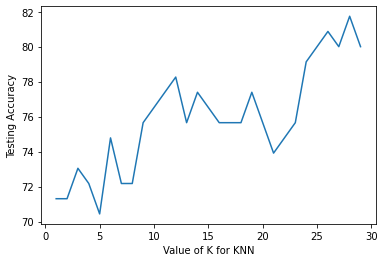

```python
plt.plot(k_range,cv_scores)
plt.xlabel('Value of K for KNN')
plt.ylabel('Testing Accuracy')
```

```python
knn = KNeighborsClassifier(n_neighbors =28)
knn.fit(X_train,y_train)
y_predict_knn=knn.predict(X_test)
print(y_predict_knn)
print(classification_report(y_test,y_predict_knn,digits=6))
print("Accuracy:",metrics.accuracy_score(y_test, y_predict_knn))
print("Precision:",metrics.precision_score(y_test, y_predict_knn))
print("Recall:",metrics.recall_score(y_test, y_predict_knn))
```

```
[0 0 1 0 0 0 1 0 0 1 0 1 0 0 0 1 0 0 0 0 0 1 0 0 0 0 0 0 0 0 0 0 1 0 0 0 0
 0 0 0 1 1 0 0 1 0 1 1 0 0 0 1 0 0 0 0 0 0 0 0 0 0 0 1 1 0 1 1 0 1 0 0 1 0
 0 0 1 0 1 0 0 0 0 0 1 1 1 1 1 0 0 0 1 0 0 0 0 0 0 0 0 0 0 0 0 0 0 1 1 0 0
 0 0 1 0]
              precision    recall  f1-score   support

           0   0.847059  0.900000  0.872727        80
           1   0.733333  0.628571  0.676923        35

    accuracy                       0.817391       115
   macro avg   0.790196  0.764286  0.774825       115
weighted avg   0.812447  0.817391  0.813135       115

Accuracy: 0.8173913043478261
Precision: 0.7333333333333333
Recall: 0.6285714285714286
```

# Applying SVM

```python
clf = SVC(kernel='linear')
clf.fit(X_train, y_train)
y_predict_svm_before = clf.predict(X_test)
```

# recall and precision without hyper parameter tuning

```python
print(classification_report(y_test,y_predict_svm_before,digits=6))

print("Accuracy:",metrics.accuracy_score(y_test, y_predict_svm_before))
print("Precision:",metrics.precision_score(y_test, y_predict_svm_before))
print("Recall:",metrics.recall_score(y_test, y_predict_svm_before))
```

```
              precision    recall  f1-score   support

           0   0.888889  0.900000  0.894410        80
           1   0.764706  0.742857  0.753623        35

    accuracy                       0.852174       115
   macro avg   0.826797  0.821429  0.824017       115
weighted avg   0.851094  0.852174  0.851562       115

Accuracy: 0.8521739130434782
Precision: 0.7647058823529411
Recall: 0.7428571428571429
```

```python
param_grid = {'C': [0.1,1, 10, 100], 'gamma': [1,0.1,0.01,0.001],'kernel': ['rbf', 'poly', 'sigmoid']}
grid = GridSearchCV(SVC(),param_grid,refit=True,verbose=2)
grid.fit(X_test,y_test)
```

[output not shown]

[output cut: 186 more lines]

[output not shown]

```
GridSearchCV(estimator=SVC(),
             param_grid={'C': [0.1, 1, 10, 100], 'gamma': [1, 0.1, 0.01, 0.001],
                         'kernel': ['rbf', 'poly', 'sigmoid']},
             verbose=2)
```

```python
print(grid.best_estimator_)
```

```
SVC(C=1, gamma=0.001)
```

```python
svm = SVC(kernel='poly',gamma=0.001, C=1)
svm.fit(X_train, y_train)
y_predict_svm_after= svm.predict(X_test)
```

```python
print(classification_report(y_test,y_predict_svm_after,digits=6))

print("Accuracy:",metrics.accuracy_score(y_test, y_predict_svm_after))
print("Precision:",metrics.precision_score(y_test, y_predict_svm_after))
print("Recall:",metrics.recall_score(y_test, y_predict_svm_after))
```

```
              precision    recall  f1-score   support

           0   0.909091  0.875000  0.891720        80
           1   0.736842  0.800000  0.767123        35

    accuracy                       0.852174       115
   macro avg   0.822967  0.837500  0.829422       115
weighted avg   0.856667  0.852174  0.853799       115

Accuracy: 0.8521739130434782
Precision: 0.7368421052631579
Recall: 0.8
```

# Desicion Tree

```python
params = {
    "criterion":("gini", "entropy"),
    "splitter":("best", "random"),
    "max_depth":(list(range(1, 20))),
    "min_samples_split":[2, 3, 4],
    "min_samples_leaf":list(range(1, 20)),
}

tree_clf_before = DecisionTreeClassifier(random_state=42)
tree_cv = GridSearchCV(tree_clf_before, params, scoring="recall", n_jobs=-1, verbose=1, cv=5)
tree_cv.fit(X_train, y_train)
best_params = tree_cv.best_params_
print(f"Best paramters: {best_params})")

tree_clf_after = DecisionTreeClassifier(**best_params)
tree_clf_after.fit(X_train, y_train)
```

```
Fitting 5 folds for each of 4332 candidates, totalling 21660 fits
Best paramters: {'criterion': 'entropy', 'max_depth': 4, 'min_samples_leaf': 9, 'min_samples_split': 2, 'splitter': 'best'})
```

```
DecisionTreeClassifier(criterion='entropy', max_depth=4, min_samples_leaf=9)
```

```python
y_predict_dtt = tree_clf_after.predict(X_train)
print(y_predict_dtt)
print(classification_report(y_train,y_predict_dtt,digits=6))
```

```
[1 0 0 1 0 1 0 1 0 0 1 0 1 0 0 0 0 1 0 0 0 1 0 0 0 0 0 0 0 1 0 1 0 1 1 0 1
 1 0 0 0 1 0 1 0 1 0 1 0 1 0 0 0 0 0 1 1 0 0 0 1 0 0 1 0 0 0 1 1 0 0 0 0 0
 1 0 0 1 0 0 1 1 0 0 1 1 1 1 0 1 1 0 1 1 1 0 1 0 0 1 0 1 0 0 0 0 0 1 0 0 0
 1 1 0 1 0 0 0 0 0 1 1 1 0 0 0 0 0 1 0 0 0 1 0 0 1 0 0 1 0 1 0 1 0 0 1 0 0
 0 0 1 0 1 1 0 0 1 1 1 0 0 0 0 0 1 1 1 1 1 0 1 1 0 1 0 1 0 0 0 0 0 0 0 1 1
 1 0 1 0 0 0 1 0 1 0 0 0 0 0 0 0 1 1 1 0 1 0 0 1 0 0 1 1 0 1 0 0 0 1 1 1 0
 0 0 0 1 0 0 0 0 1 0 0 0 0 0 0 0 0 0 0 0 0 0 0 1 0 0 1 0 1 0 1 1 0 0 1 1 0
 0 0 1 0 1 1 0 0 1 1 1 0 0 1 0 0 0 0 1 0 0 0 1 0 0 1 0 0 1 1 1 1 0 0 0 0 0
 0 0 0 1 0 1 1 0 0 1 1 1 0 0 0 0 1 1 0 0 0 1 0 0 0 1 0 0 0 0 0 0 0 1 0 0 1
 0 0 0 1 1 1 0 0 1 1 0 0 0 0 0 0 0 0 0 1 1 0 0 1 0 0 0 1 1 1 0 0 0 0 1 0 0
 1 0 1 0 0 1 1 1 0 0 1 1 0 1 0 0 1 0 0 0 0 0 0 1 0 0 1 0 0 0 0 0 0 0 0 1 1
 1 1 0 1 1 0 0 0 0 0 0 0 0 0 0 0 1 0 1 0 0 0 0 1 0 1 0 0 0 0 1 1 1 0 1 1 1
 1 0 1 1 1 1 0 1 0 0 1 1 0 1 0 0 1 0 1 0 0 1 0 0 1 1 0 0 1 1 0 1 0 0 0 1 0
 0 0 0 0 1 0 0 0 0 0 1 1 0 0 0 1 0 1 0 0 0 1 1 1 0 0 1 0 1 1 1 0 0 1 1 1 0
 0 1 1 0 1 0 1 0 0 0 0 0 0 0 1 1 1 0 0 0 0 0 0 1 0 0 0 1 1 0 0 1 0 1 1 1 0
 1 0 1 0 1 1 1 0 0 0 1 1 0 0 0 1 0 0 1 0 0 0 0 0 0 1 0 1 0 0 1 0 0 0 0 1 0
 1 0 1 0 0 0 0 0 1 1 0 0 0 0 0 1 1 0 1 0 1 0 1 0 0 1 1 1 0 1 0 0 1 1 1 1 0
 1 0 1 1 0 0 1 1 0 1 0 1 0 0 1 1 0 1 0 0 0]
              precision    recall  f1-score   support

           0   0.850746  0.814286  0.832117       420
           1   0.685484  0.739130  0.711297       230

    accuracy                       0.787692       650
   macro avg   0.768115  0.776708  0.771707       650
weighted avg   0.792269  0.787692  0.789365       650
```

```python
y_predict_dt =tree_clf_after.predict(X_test)
print(y_predict_dt)
print(classification_report(y_test,y_predict_dt,digits=6))
print("Accuracy:",metrics.accuracy_score(y_test, y_predict_dt))
print("Precision:",metrics.precision_score(y_test, y_predict_dt))
print("Recall:",metrics.recall_score(y_test, y_predict_dt))
```

```
[0 0 1 0 0 1 1 0 0 1 0 1 1 0 0 0 0 0 0 1 1 0 0 0 0 0 1 1 0 1 0 0 1 0 0 0 1
 0 0 0 0 1 0 0 1 0 0 0 0 0 0 1 0 0 0 0 0 0 1 0 0 0 0 1 1 0 1 0 0 1 1 0 0 1
 0 0 1 0 0 0 1 0 0 0 1 1 0 1 1 0 1 1 1 0 0 1 1 0 1 0 0 0 0 0 0 0 0 1 1 0 0
 0 0 1 0]
              precision    recall  f1-score   support

           0   0.844156  0.812500  0.828025        80
           1   0.605263  0.657143  0.630137        35

    accuracy                       0.765217       115
   macro avg   0.724710  0.734821  0.729081       115
weighted avg   0.771449  0.765217  0.767799       115

Accuracy: 0.7652173913043478
Precision: 0.6052631578947368
Recall: 0.6571428571428571
```

```python
y_predict=tree_clf_after.fit(X_train, y_train)
dot_data = export_graphviz(tree_clf_after, out_file=None,
                           feature_names=X.columns,
                           class_names=['No', 'Yes'],
                           filled=True, rounded=True,
                           special_characters=True)
graph = graphviz.Source(dot_data)
graph
```

[figure not shown]

# Logistic Regression

```python
logreg = LogisticRegression(max_iter=5000,C=3)
logreg.fit(X_train,y_train)
logreg = Pipeline([('log_reg', logreg)])
logreg.fit(X_train,y_train)
y_predict_logreg=logreg.predict(X_test)
print(y_predict_logreg)
print(classification_report(y_test,y_predict_logreg,digits=6))
```

```
[0 0 1 0 0 0 1 0 1 1 0 0 1 0 0 1 0 0 0 0 0 1 0 0 0 0 0 1 0 1 0 0 1 0 0 0 0
 0 0 0 1 1 0 0 1 0 1 1 0 0 0 1 0 0 0 0 0 0 0 0 0 0 1 1 1 0 1 0 0 1 1 0 1 0
 0 0 1 0 1 0 0 1 0 0 1 1 0 1 1 0 0 0 1 0 0 0 1 0 1 0 0 0 0 0 0 0 0 1 1 0 0
 0 1 1 0]
              precision    recall  f1-score   support

           0   0.897436  0.875000  0.886076        80
           1   0.729730  0.771429  0.750000        35

    accuracy                       0.843478       115
   macro avg   0.813583  0.823214  0.818038       115
weighted avg   0.846395  0.843478  0.844662       115
```

```python
print("Accuracy:",metrics.accuracy_score(y_test, y_predict_logreg))
print("Precision:",metrics.precision_score(y_test, y_predict_logreg))
print("Recall:",metrics.recall_score(y_test, y_predict_logreg))
```

```
Accuracy: 0.8434782608695652
Precision: 0.7297297297297297
Recall: 0.7714285714285715
```

# Random Classifier

```python
rf_model = RandomForestClassifier(random_state=46)
rf_model.fit(X_train,y_train)
y_predict_rc=rf_model.predict(X_test)
print(y_predict_rc)
print(classification_report(y_test,y_predict_rc,digits=6))
print("Accuracy:",metrics.accuracy_score(y_test, y_predict_rc))
print("Precision:",metrics.precision_score(y_test, y_predict_rc))
print("Recall:",metrics.recall_score(y_test, y_predict_rc))
```

```
[1 0 1 0 0 0 1 0 0 0 0 0 0 0 0 1 0 0 0 0 0 1 0 0 0 0 0 1 0 1 0 0 1 0 0 0 0
 0 0 0 1 1 0 0 1 0 1 1 0 0 0 1 0 0 0 0 0 0 0 0 0 0 0 1 1 0 1 0 0 1 0 0 0 0
 0 0 1 0 1 0 0 0 0 0 1 1 0 1 1 0 1 1 1 0 0 0 1 0 1 0 0 0 0 0 0 0 0 1 1 0 0
 0 0 1 0]
              precision    recall  f1-score   support

           0   0.879518  0.912500  0.895706        80
           1   0.781250  0.714286  0.746269        35

    accuracy                       0.852174       115
   macro avg   0.830384  0.813393  0.820987       115
weighted avg   0.849610  0.852174  0.850225       115

Accuracy: 0.8521739130434782
Precision: 0.78125
Recall: 0.7142857142857143
```